# Shields

We implemented weapons, but now our ships need defenses! To balance things out, we’ll work on shields in this lesson.

Shields are capable of stopping lasers entirely, and they lose one hitpoint for each incoming projectile.

The player needs first to disable the enemy ship’s shield for their laser weapons to take effect.

This is one reason why I decided to implement the one-shot laser-firing policy for the player as they have to time it properly.

In this lesson, we cover:

- Adding shields to *ShipTemplate*, so both player and AI ships get one.
- Shield interactions with projectile and laser weapons. They lose one hitpoint for each incoming projectile and stop lasers entirely.
- Shield recharge up to a maximum number of hitpoints.
- The player shield on and off UI option using the *UISystem* scene. This doesn’t have any real impact on the demo because we won’t go as far as implementing a power-management system. It serves as an example for you to extend at your discretion.

Here’s a demo of how the shields interact with our weapons:

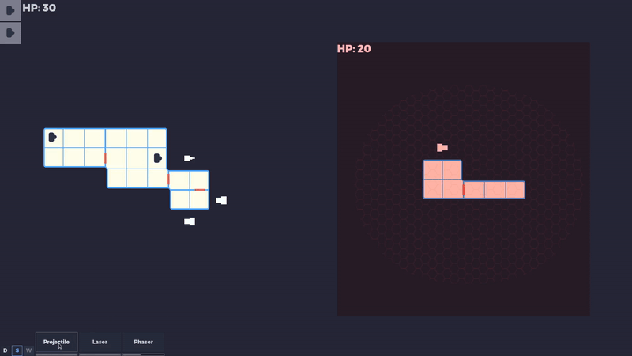

## The shield scene

We start as usual by creating a new scene file. Pick the

[figure not shown]

`Area2D` as the root node and rename it to *Shield*.

Continue by adding the following scene tree:

[figure not shown]

The default values on the *Shield* node are acceptable for our needs. We’ll overwrite the *Collision Mask* property from code based on which ship the *Shield* is on.

Moving on to the

[figure not shown]

`CollisionShape2D`, assign a

[figure not shown]

`CapsuleShape2D` resource to the `Shape` property.

We’ll change the *Radius* and *Height* through a `tool` script on the *Shield* node so that we don’t have to bother with using the *Editable Children* option.

Make sure to enable *Resource -> Local To Scene* in case you want to change the size of one shield but not the other.

Finally, set *Transform -> Rotation Degrees* to `90` so the capsule is horizontal.

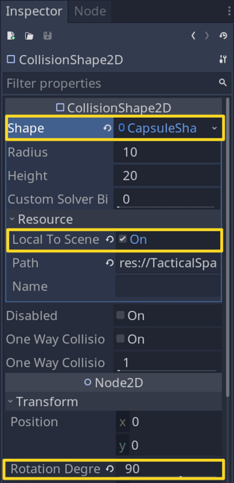

You should have the following result:

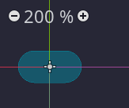

For the

[figure not shown]

`Polygon2D`, we use this node to draw the shield texture you saw in the demo video from the introduction.

We set the

[figure not shown]

`Polygon2D`’s data points from code, so all you have to set are the following properties:

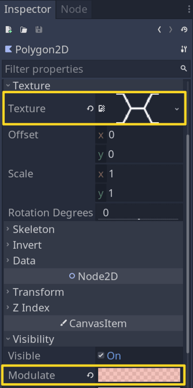

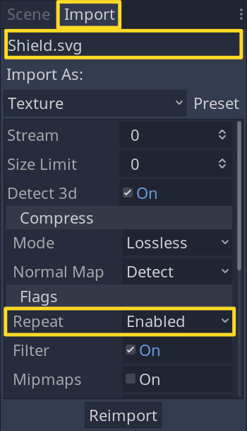

We don’t need to change any property on

[figure not shown]

`Timer` because we manipulate it from code.

This brings us to the next part - coding our *Shield* scene.

Save the scene file at `res://TacticalSpaceCombat/Ship/Shield.tscn`, and we are ready to move onto coding.

## Coding the shield

To finish up working on the *Shield* scene, add a script to the root node, and start by declaring the top lines of code:

```
tool
extends Area2D
```

We make it a `tool` script so we can get real-time feedback in the editor when changing the `radius` and `height` export variables we’ll introduce right away:

```
## The player can turn on and off shields. It's for demo purposes to see how we
## use the `UISystem` button scene in practice.
export var powered := true setget set_powered

export var hitpoints_max := 4
export var charge_time := 5
export var radius := 300 setget set_radius
export var height := 100 setget set_height
```

The *Shield* has hitpoints, and only when they hit `0`, will we let the shots pass.

Lets continue with the rest of the variables:

```
## Start with 0 `hitpoints` at the beginning of the game.
var hitpoints := 0 setget set_hitpoints

## We keep track of the shield status with `is_on`. It gets updated in
## `set_hitpoints`.
var is_on := false
```

The final variables are references to the nodes:

```
onready var collision_shape: CollisionShape2D = $CollisionShape2D
onready var polygon: Polygon2D = $Polygon2D
onready var timer: Timer = $Timer
```

We now move to the `setup()` and `_ready()` functions:

```
func setup(mean_position: Vector2, mask: int) -> void:
    # We use the mean rooms position so we don't have to worry about placing the
    # shield ourselves.
    position = mean_position

    # We also update `collision_mask` based on which ship this `Shield` belongs
    # to.
    collision_mask = mask


func _ready() -> void:
    # Since this is a tool script we skip `_ready()` in the editor.
    # But before that, we trigger the setter functions with the stored
    # export variables to update `CollisionShape2D`.
    self.radius = radius
    self.height = height
    if Engine.editor_hint:
        return

    # Connection for projectiles.
    connect("body_entered", self, "_on_body_entered")
    timer.connect("timeout", self, "_on_Timer_timeout")

    # We give visual feedback on the shield hitpoints based on transparency.
    # We're using `self_modulate` because we already set `modulate` from the
    # _Inspector_, and that value represents the maximum opacity the shield can
    # have.
    polygon.self_modulate.a = 0

    # We calculate the shape of the polygon that shows the texture based on the
    # collision shape with the help of `_get_shape_points()`.
    polygon.polygon = _get_shape_points()

    timer.wait_time = charge_time

    # Start charging the shield (increase hitpoints) only if it's powered on.
    if powered:
        timer.start()
```

Let’s add the functions that we connect the signals to:

```
func _on_Timer_timeout() -> void:
    # Use `self.` to call `set_hitpoints()` each time we increase the value.
    self.hitpoints += 1


func _on_body_entered(body: Node) -> void:
    # Decrease hitpoints on projectile collision, restart the charge timer and
    # remove the projectile.
    if is_on:
        self.hitpoints -= 1
        timer.start()
        body.queue_free()
```

The next function is `_get_shape_points()`. This is a function based on a backend implementation for

[figure not shown]

`CollisionShape2D`.

```
func _get_shape_points() -> PoolVector2Array:
    var out := PoolVector2Array()
    var weight := TAU / 24.0
    var shape: CapsuleShape2D = collision_shape.shape
    for i in range(24):
        var offset := Vector2(0, 0.5 * shape.height * (-1 if i > 6 and i <= 18 else 1))
        out.push_back(shape.radius * Vector2(sin(weight * i), cos(weight * i)) + offset)
        if i == 6 or i == 18:
            out.push_back(shape.radius * Vector2(sin(weight * i), cos(weight * i)) - offset)
    return collision_shape.transform.xform(out)
```

The details aren’t important. It sets the

[figure not shown]

`Polygon2D` data points to the same points as the

[figure not shown]

`CapsuleShape2D` resource assigned to

[figure not shown]

`CollisionShape2D`.

This way, we get the same capsule shape for

[figure not shown]

`Polygon2D` that the

[figure not shown]

`CollisionShape2D` shows us in the editor.

You can compare it with the back-end implementation from [capsule_shape_2d.cpp](https://github.com/godotengine/godot/blob/277db14b647d3184b341a359020c0acc4549afaf/scene/resources/capsule_shape_2d.cpp#L37) if you want.

We finish the script with the setter functions:

```
func set_powered(value: bool) -> void:
    powered = value
    self.hitpoints = 0
    if timer != null:
        timer.call("start" if powered else "stop")


func set_radius(value: int) -> void:
    radius = value
    if collision_shape != null:
        collision_shape.shape.radius = radius


func set_height(value: int) -> void:
    height = value
    if collision_shape != null:
        collision_shape.shape.height = height


func set_hitpoints(value: int) -> void:
    # Make sure to restrict `hitpoints` to the `[0, hitpoints_max]` range.
    hitpoints = clamp(value, 0, hitpoints_max)
    is_on = hitpoints > 0
    if polygon != null and timer != null:
        polygon.self_modulate.a = hitpoints / float(hitpoints_max)
        timer.call("stop" if hitpoints == hitpoints_max else "start")
```

We’re now ready to move on to instantiating the new *Shield* scene into *ShipTemplate*.

## Adding shield to ships

Open the *ShipTemplate* scene and add *Shield* at the end of the tree:

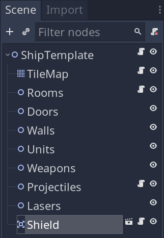

Ship*Player* and *ShipAI* will both update to reflect the changes in *ShipTemplate*, for example:

[figure not shown]

You can change the parameters on *ShipPlayer -> Shield* and *ShipAI -> Shield* as desired.

For my tests, I only changed *Charge Time* to `3` for *ShipPlayer* and `2` for *ShipAI*, respectively.

We need to update a few more scripts to complete the *Shield* implementation.

## Laser weapons interaction

When the shield is on, we cut off the laser line based on the capsule shape:

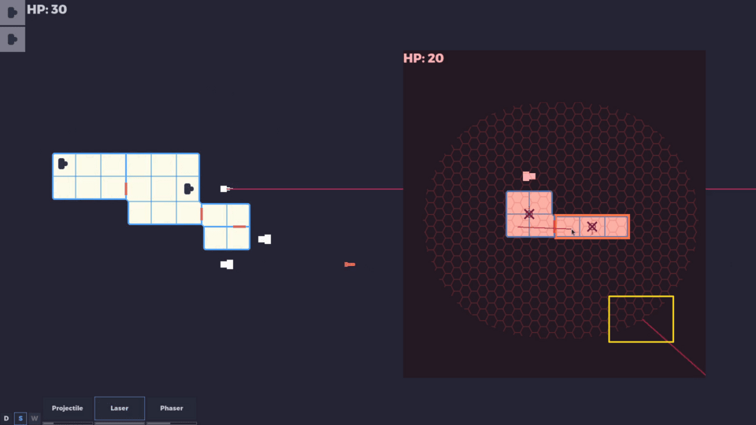

To implement this, we need to update the `LaserTracker.gd` script. Open the script if you haven’t done so yet.

We start by introducing a few new variables:

```
var _shield: Area2D = null
var _shield_polygon := PoolVector2Array()
```

We assign values to these in `setup()`:

```
## NOTE that we also pass in the new `shield` parameter.
func setup(color: Color, rooms: Node2D, shield: Area2D) -> void:
    # _rooms = rooms
    _shield = shield
    # The `_shield_polygon` data needs to be transformed based on the `_shield`
    # location as the data itself is centered at the origin.
    _shield_polygon = _shield.polygon.polygon
    _shield_polygon = _shield.transform.xform(_shield_polygon)
    # ...
```

Now that we have a reference to the *Shield* and the positioning of the polygon data, we can clip the incoming laser line if the *Shield* is on. We do this in `_swipe_laser()`:

```
func _swipe_laser(offset: Vector2) -> void:
    # line.points[1] = offset
    # We insert the code between the former two lines because inside the if
    # statement we update `line.points`, and `area.position` depends on this.
    if _shield.is_on:
        for points in Geometry.clip_polyline_with_polygon_2d(line.points, _shield_polygon):
            line.points = points
    # area.position = line.points[1]
```

We’re using a built-in function from the `Geometry` object called `clip_polyline_with_polygon_2d()`. “*This* operation can be thought of as cutting a line with a closed shape” - which is a direct quote from the documentation.

That’s all we need to do to update *LaserTracker*.

We now move to update the `ShipTemplate.gd` script, where we call the `setup()` functions.

## Updating the ship script

Open the `ShipTemplate.gd` script if you haven’t done so, and let’s start by declaring a reference to the new *Shield* node:

```
# ...
# onready var lasers: Node2D = $Lasers
onready var shield: Area2D = $Shield
```

We need to call the `shield.setup()` function in `_ready_not_editor_hint()`:

```
func _ready_not_editor_hint() -> void:
    # ...
    # projectiles.setup(rooms.mean_position)
    shield.setup(
        rooms.mean_position,
        Global.Layers.SHIPPLAYER if is_in_group("player") else Global.Layers.SHIPAI
    )
```

We also update `laser_tracker.setup()` call since we added a new parameter to the function:

```
 func add_laser_tracker(color: Color) -> Node:
    var laser_tracker := LaserTracker.instance()
    lasers.add_child(laser_tracker)
-   laser_tracker.setup(color, rooms)
+ laser_tracker.setup(color, rooms, shield)
  return laser_tracker
```

That’s all we need to update in the `ShipTemplate.gd` script.

*Note* that as we cut the laser line at the boundary of the *Shield*, the

[figure not shown]

`Area2D` that interacts with the rooms normally also follows this updated path:

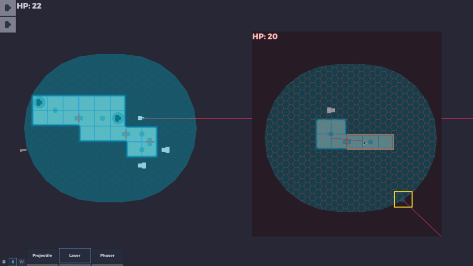

This means that the *Shield* scene shields the ship from the laser weapon interaction quite literally, so we don’t have to implement any other checks before taking damage in `_on_RoomArea2D_area_entered()`.

## The ship UI button

We are left with adding the player UI button associated with the *Shield* system:

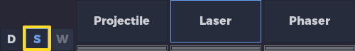

This is for demonstration purposes and doesn’t offer any real in-game advantage. We would typically have a power-management system and divert power from one system to another, but this is outside the scope of this course.

Remember that we made a universal *UISystem* button scene that we used for the doors system. This is why we made it universal - so we can use it with other systems as well.

Open the `TacticalSpaceCombat.gd` script, and let’s start by preloading the *UISystem* scene:

```
# ...
# const UIWeapon = preload("TacticalSpaceCombat/UI/UIWeapon.tscn")
const UISystem = preload("TacticalSpaceCombat/UI/UISystem.tscn")
```

We separate the *Shield*-related code into the separate `_ready_shield()` function to keep it organized:

```
func _ready_shield() -> void:
    var ui_shield := UISystem.instance()

    # The `toggled` signal sends the pressed state as a boolean value, which
    # means we can connect it directly to the player `shield.powered` setter
    # function.
    ui_shield.connect("toggled", ship_player.shield, "set_powered")

    # We need to turn `UISystem` into a toggle button.
    ui_shield.toggle_mode = true

    # And update its `pressed` and `disabled` states to reflect the
    # `shield.powered` property.
    ui_shield.pressed = ship_player.shield.powered
    ui_shield.disabled = not ship_player.shield.powered

    # Call it `S` as shorthand for `Shield`.
    ui_shield.text = "S"
    ui_systems.add_child(ui_shield)
```

We’re left with updating the `_ready()` function to call `_ready_shield()`:

```
func _ready() -> void:
    # ...
    _ready_shield()
    # _ready_units()
```

*Note* that the order in which we call the `_ready_*()` functions matters because we add them one by one to the scene tree as children to the *Systems* node.

## Conclusion

In this lesson, we created a clever *Shield* system that quite literally restricts weapon interaction with the ships by prohibiting projectiles and lasers from interacting with the rooms.

This only works if the shield is large enough to encompass the entire ship.

To customize the shape of the

[figure not shown]

`CapsuleShape2D` resource, we hooked up exported variables on the *Shield* node.

We finished the lesson by introducing a UI button to demonstrate how to sync the universal *UISystem* scene with the *Shield*.

It’s up to you now to expand on this example and create perhaps a full-fledged power-management system.

In the next lesson, we cover *Hazards* (fire and hull breach) and unit hitpoints.

## Code reference

`res://TacticalSpaceCombat/Ship/Shield.gd`:

```
tool
extends Area2D

export var powered := true setget set_powered
export var hitpoints_max := 4
export var charge_time := 5
export var radius := 300 setget set_radius
export var height := 100 setget set_height

var hitpoints := 0 setget set_hitpoints
var is_on := false

onready var collision_shape: CollisionShape2D = $CollisionShape2D
onready var polygon: Polygon2D = $Polygon2D
onready var timer: Timer = $Timer


func setup(mean_position: Vector2, mask: int) -> void:
    position = mean_position
    collision_mask = mask


func _ready() -> void:
    self.radius = radius
    self.height = height
    if Engine.editor_hint:
        return

    connect("body_entered", self, "_on_body_entered")
    timer.connect("timeout", self, "_on_Timer_timeout")
    polygon.self_modulate.a = 0
    polygon.polygon = _get_shape_points()
    timer.wait_time = charge_time
    if powered:
        timer.start()


func _on_Timer_timeout() -> void:
    self.hitpoints += 1


func _on_body_entered(body: Node) -> void:
    if is_on:
        self.hitpoints -= 1
        timer.start()
        body.queue_free()


func _get_shape_points() -> PoolVector2Array:
    var out := PoolVector2Array()
    var weight := TAU / 24.0
    var shape: CapsuleShape2D = collision_shape.shape
    for i in range(24):
        var offset := Vector2(0, 0.5 * shape.height * (-1 if i > 6 and i <= 18 else 1))
        out.push_back(shape.radius * Vector2(sin(weight * i), cos(weight * i)) + offset)
        if i == 6 or i == 18:
            out.push_back(shape.radius * Vector2(sin(weight * i), cos(weight * i)) - offset)
    return collision_shape.transform.xform(out)


func set_powered(value: bool) -> void:
    powered = value
    self.hitpoints = 0
    if timer != null:
        timer.call("start" if powered else "stop")


func set_radius(value: int) -> void:
    radius = value
    if collision_shape != null:
        collision_shape.shape.radius = radius


func set_height(value: int) -> void:
    height = value
    if collision_shape != null:
        collision_shape.shape.height = height


func set_hitpoints(value: int) -> void:
    hitpoints = clamp(value, 0, hitpoints_max)
    is_on = hitpoints > 0
    if polygon != null and timer != null:
        polygon.self_modulate.a = hitpoints / float(hitpoints_max)
        timer.call("stop" if hitpoints == hitpoints_max else "start")
```

`res://TacticalSpaceCombat/Ship/Weapons/LaserTracker.gd`:

```
extends Node2D

signal targeted(msg)

const LINE_DEFAULT := PoolVector2Array([Vector2.INF, Vector2.INF])

var _is_targeting := false
var _targeting_length := 0
var _rng := RandomNumberGenerator.new()
var _rooms: Node2D = null
var _shield: Area2D = null
var _shield_polygon := PoolVector2Array()

onready var tween: Tween = $Tween
onready var area: Area2D = $Area2D
onready var line: Line2D = $Line2D
onready var target_line: Line2D = $TargetLine2D


func setup(color: Color, rooms: Node2D, shield: Area2D) -> void:
    _rooms = rooms
    _shield = shield
    _shield_polygon = _shield.polygon.polygon
    _shield_polygon = _shield.transform.xform(_shield_polygon)
    line.default_color = color
    target_line.default_color = color


func _ready() -> void:
    _rng.randomize()
    target_line.points = LINE_DEFAULT
    line.points = LINE_DEFAULT


func _unhandled_input(event: InputEvent) -> void:
    if not (event is InputEventMouse and _is_targeting):
        return

    if event.is_action_pressed("left_click"):
        target_line.points[0] = get_local_mouse_position()
    elif target_line.points[0] != Vector2.INF and event is InputEventMouseMotion:
        var offset: Vector2 = get_local_mouse_position() - target_line.points[0]
        offset = offset.clamped(_targeting_length)
        target_line.points[1] = target_line.points[0] + offset
    elif event.is_action_released("left_click") and target_line.points[1] != Vector2.INF:
        _is_targeting = false
        emit_signal("targeted", {"type": Controller.Type.LASER})


func _on_Controller_targeting(msg: Dictionary) -> void:
    match msg:
        {"targeting_length": var targeting_length, "is_targeting": var is_targeting}:
            _is_targeting = is_targeting
            _targeting_length = targeting_length
            if _is_targeting:
                target_line.points = LINE_DEFAULT
        {"targeting_length": var targeting_length}:
            target_line.points = _rooms.get_laser_points(targeting_length)
            emit_signal("targeted", {"type": Controller.Type.LASER})


func _on_Weapon_fire_started(params: Dictionary) -> void:
    if Vector2.INF in target_line.points:
        return

    area.set_deferred("monitorable", true)
    area.params = params

    line.points[0] = _rooms.mean_position + Utils.randvf_circle(_rng, Projectile.MAX_DISTANCE)
    tween.interpolate_method(
        self, "_swipe_laser", target_line.points[0], target_line.points[1], params.duration
    )
    tween.start()


func _on_Weapon_fire_stopped() -> void:
    tween.remove_all()
    target_line.points = LINE_DEFAULT
    line.points = LINE_DEFAULT
    area.position = Vector2.ZERO
    area.set_deferred("monitorable", false)


func _swipe_laser(offset: Vector2) -> void:
    line.points[1] = offset
    if _shield.is_on:
        for points in Geometry.clip_polyline_with_polygon_2d(line.points, _shield_polygon):
            line.points = points
    area.position = line.points[1]
```

`res://TacticalSpaceCombat/Ship/ShipTemplate.gd`:

```
tool
extends Node2D

signal hitpoints_changed(hitpoints, is_player)

const LaserTracker := preload("Weapons/LaserTracker.tscn")
const AttackLabel := preload("Weapons/AttackLabel.tscn")

export (int, 0, 30) var hitpoints := 30

var _slots := {}

onready var tilemap: TileMap = $TileMap
onready var rooms: Node2D = $Rooms
onready var doors: Node2D = $Doors
onready var units: Node2D = $Units
onready var weapons: Node2D = $Weapons
onready var projectiles: Node2D = $Projectiles
onready var lasers: Node2D = $Lasers
onready var shield: Area2D = $Shield


func _ready() -> void:
    call("_ready_editor_hint" if Engine.editor_hint else "_ready_not_editor_hint")


func _ready_editor_hint() -> void:
    for room in rooms.get_children():
        room.setup(tilemap)


func _ready_not_editor_hint() -> void:
    for unit in units.get_children():
        for door in doors.get_children():
            door.connect("opened", unit, "set_is_walking", [true])

        var position_map := tilemap.world_to_map(unit.path_follow.position)
        _slots[position_map] = unit

    for room in rooms.get_children():
        room.connect("area_entered", self, "_on_RoomArea2D_area_entered", [room])
        room.hit_area.connect("body_entered", self, "_on_RoomHitArea2D_body_entered", [room])
        room.setup(tilemap)

        for point in room:
            tilemap.set_cellv(point, 0)

    tilemap.setup(rooms, doors)
    projectiles.setup(rooms.mean_position)
    shield.setup(
        rooms.mean_position,
        Global.Layers.SHIPPLAYER if is_in_group("player") else Global.Layers.SHIPAI
    )


func _get_configuration_warning() -> String:
    var is_verified := (
        is_in_group("player")
        and weapons.get_child_count() <= 4
        or not is_in_group("player")
    )
    return "" if is_verified else "%s can't have more than 4 weapons!" % name


func _unhandled_input(event: InputEvent) -> void:
    if not event.is_action_pressed("right_click"):
        return

    for unit in get_tree().get_nodes_in_group("selected-unit"):
        var point1: Vector2 = tilemap.world_to_map(unit.path_follow.position)
        for room in get_tree().get_nodes_in_group("selected-room"):
            if not room.owner.is_in_group("player"):
                break

            var point2: Vector2 = room.get_slot(_slots, unit)
            if is_inf(point2.x):
                break

            var path: Curve2D = tilemap.find_path(point1, point2)
            Utils.erase_value(_slots, unit)
            _slots[point2] = unit
            unit.walk(path)


func _on_UIDoorsButton_pressed() -> void:
    var has_opened_doors := false
    for door in doors.get_children():
        if door.is_open:
            has_opened_doors = true
            break

    for door in doors.get_children():
        door.is_open = not has_opened_doors


func _on_RoomHitArea2D_body_entered(body: RigidBody2D, room: Room) -> void:
    if not room.position.is_equal_approx(body.params.target_position):
        return

    body.queue_free()
    _take_damage(body.params.attack, room.position)


func _on_RoomArea2D_area_entered(area: Area2D, room: Room) -> void:
    if area.is_in_group("laser"):
        _take_damage(area.params.attack, room.position)


func add_laser_tracker(color: Color) -> Node:
    var laser_tracker := LaserTracker.instance()
    lasers.add_child(laser_tracker)
    laser_tracker.setup(color, rooms, shield)
    return laser_tracker


func _take_damage(attack: int, object_position: Vector2) -> void:
    var attack_label := AttackLabel.instance()
    attack_label.setup(attack, object_position)
    add_child(attack_label)

    hitpoints -= attack
    hitpoints = max(0, hitpoints)
    emit_signal("hitpoints_changed", hitpoints, is_in_group("player"))
```

`res://TacticalSpaceCombat.gd`:

```
extends Node2D

const UIUnit = preload("TacticalSpaceCombat/UI/UIUnit.tscn")
const UIWeapons = preload("TacticalSpaceCombat/UI/UIWeapons.tscn")
const UIWeapon = preload("TacticalSpaceCombat/UI/UIWeapon.tscn")
const UISystem = preload("TacticalSpaceCombat/UI/UISystem.tscn")

const END_SCENE = "TacticalSpaceCombat/End.tscn"

onready var ship_player: Node2D = $ShipPlayer
onready var ship_ai: Node2D = $ViewportContainer/Viewport/ShipAI
onready var ui_units: VBoxContainer = $UI/Units
onready var ui_doors: Button = $UI/Systems/Doors
onready var ui_systems: HBoxContainer = $UI/Systems
onready var ui_hitpoints_player: Label = $UI/HitPoints
onready var ui_hitpoints_ai: Label = $ViewportContainer/Viewport/UI/HitPoints


func _ready() -> void:
    ship_player.connect("hitpoints_changed", self, "_on_Ship_hitpoints_changed")
    ship_ai.connect("hitpoints_changed", self, "_on_Ship_hitpoints_changed")
    ui_doors.connect("pressed", ship_player, "_on_UIDoorsButton_pressed")

    _ready_shield()
    _ready_units()
    _ready_weapons_ai()
    _ready_weapons_player()

    _on_Ship_hitpoints_changed(ship_player.hitpoints, true)
    _on_Ship_hitpoints_changed(ship_ai.hitpoints, false)


func _ready_units() -> void:
    for unit in ship_player.units.get_children():
        var ui_unit: ColorRect = UIUnit.instance()
        ui_units.add_child(ui_unit)
        unit.setup(ui_unit)


func _ready_weapons_ai() -> void:
    for controller in ship_ai.weapons.get_children():
        if controller is ControllerAIProjectile:
            controller.connect("targeting", ship_player.rooms, "_on_Controller_targeting")
            controller.weapon.connect(
                "projectile_exited", ship_player.projectiles, "_on_Weapon_projectile_exited"
            )
            ship_player.rooms.connect("targeted", controller, "_on_Ship_targeted")
        elif controller is ControllerAILaser:
            var laser_tracker: Node = ship_player.add_laser_tracker(controller.weapon.color)
            controller.connect(
                "targeting", laser_tracker, "_on_Controller_targeting", [], CONNECT_DEFERRED
            )
            controller.weapon.connect("fire_started", laser_tracker, "_on_Weapon_fire_started")
            controller.weapon.connect("fire_stopped", laser_tracker, "_on_Weapon_fire_stopped")
            laser_tracker.connect("targeted", controller, "_on_Ship_targeted")


func _ready_weapons_player() -> void:
    for controller in ship_player.weapons.get_children():
        if not ui_systems.has_node("Weapons"):
            ui_systems.add_child(UIWeapons.instance())
        var ui_weapon: VBoxContainer = UIWeapon.instance()
        ui_systems.get_node("Weapons").add_child(ui_weapon)

        if controller is ControllerPlayerProjectile:
            controller.weapon.connect(
                "projectile_exited", ship_ai.projectiles, "_on_Weapon_projectile_exited"
            )
            for room in ship_ai.rooms.get_children():
                controller.connect("targeting", room, "_on_Controller_targeting")
                room.connect("targeted", controller, "_on_Ship_targeted")

        elif controller is ControllerPlayerLaser:
            var laser_tracker: Node = ship_ai.add_laser_tracker(controller.weapon.color)
            controller.connect(
                "targeting", laser_tracker, "_on_Controller_targeting", [], CONNECT_DEFERRED
            )
            controller.weapon.connect("fire_started", laser_tracker, "_on_Weapon_fire_started")
            controller.weapon.connect("fire_stopped", laser_tracker, "_on_Weapon_fire_stopped")
            laser_tracker.connect("targeted", controller, "_on_Ship_targeted")
        controller.setup(ui_weapon)


func _ready_shield() -> void:
    var ui_shield := UISystem.instance()
    ui_shield.connect("toggled", ship_player.shield, "set_powered")
    ui_shield.toggle_mode = true
    ui_shield.pressed = ship_player.shield.powered
    ui_shield.disabled = not ship_player.shield.powered
    ui_shield.text = "S"
    ui_systems.add_child(ui_shield)


func _on_Ship_hitpoints_changed(hitpoints: int, is_player: bool) -> void:
    var label := ui_hitpoints_player if is_player else ui_hitpoints_ai
    label.text = "HP: %d" % hitpoints
    if hitpoints == 0:
        Global.winner_is_player = not is_player
        get_tree().change_scene(END_SCENE)
```